[figure not shown]

# Instructions

- Some parts of the code are already done for you
- You need to execute all the cells
- You need to add the code where ever you see `"#### Add your code here ####"`
- Marks are mentioned along with the cells

# Face recognition

Task is to recognize a faces

### Dataset

**Aligned Face Dataset from Pinterest**

```python
import tensorflow
tensorflow.__version__
```

```
'2.2.0'
```

#### Mount Google drive if you are using google colab

- We recommend using Google Colab as you can face memory issues and longer runtimes while running on local

```python
from google.colab import drive
drive.mount('/content/drive')

## skipping  running on local system
```

[output not shown]

#### Change current working directory to project folder (1 mark)

```python
#### Add your code here ####

import os
import pandas as pd
project_path=os.getcwd()
project_path
```

```
'D:\\PG-AIML\\Labs\\Assessment\\Project14-Advance Computer Vision with CNN__Project_FaceRecognition'
```

### Extract the zip file (2 marks)

- Extract Aligned Face Dataset from Pinterest.zip

```python
#### Add your code here ####
#Unzip the file
!tar -xf "Aligned Face Dataset.zip"
```

[output not shown]

[output cut: 170 more lines]

```python
ls -l
```

[output not shown]

[output cut: 188 more lines]

```
 Volume in drive D is Rashmi
 Volume Serial Number is 3EEC-1A59

 Directory of D:\PG-AIML\Labs\Assessment\Project14-Advance Computer Vision with CNN__Project_FaceRecognition
```

[output not shown]

[output cut: 143 more lines]

### Function to load images

- Define a function to load the images from the extracted folder and map each image with person id

```python
import numpy as np
import os

class IdentityMetadata():
    def __init__(self, base, name, file):
        # print(base, name, file)
        # dataset base directory
        self.base = base
        # identity name
        self.name = name
        # image file name
        self.file = file

    def __repr__(self):
        return self.image_path()

    def image_path(self):
        return os.path.join(self.base, self.name, self.file)

def load_metadata(path):
    metadata = []
    for i in os.listdir(path):
        for f in os.listdir(os.path.join(path, i)):
            # Check file extension. Allow only jpg/jpeg' files.
            ext = os.path.splitext(f)[1]
            if ext == '.jpg' or ext == '.jpeg':
                metadata.append(IdentityMetadata(path, i, f))
    return np.array(metadata)

# metadata = load_metadata('images')
metadata = load_metadata(project_path+'//PINS')
```

### Define function to load image

- Define a function to load image from the metadata

```python
import cv2
def load_image(path):
    img = cv2.imread(path, 1)
    # OpenCV loads images with color channels
    # in BGR order. So we need to reverse them
    return img[...,::-1]
```

#### Load a sample image (2 marks)

- Load one image using the function "load_image"

```python
#### Add your code here ####
load_image(project_path+'//PINS//pins_Aaron Paul//Aaron Paul0_262.jpg')
```

```
array([[[233, 188, 165],
        [231, 186, 163],
        [220, 178, 156],
        ...,
        [106,  63,  72],
        [106,  63,  72],
        [106,  63,  72]],

       [[232, 187, 164],
        [233, 188, 165],
        [220, 178, 156],
        ...,
        [106,  63,  72],
        [106,  63,  72],
        [106,  63,  72]],

       [[230, 186, 161],
        [228, 184, 159],
        [206, 164, 140],
        ...,
        [106,  63,  72],
        [106,  63,  72],
        [106,  63,  72]],

       ...,

       [[198, 118,  91],
        [197, 120,  94],
        [195, 119,  95],
        ...,
        [ 78,  66,  76],
        [ 78,  66,  76],
        [ 78,  66,  76]],

       [[200, 120,  93],
        [200, 120,  93],
        [198, 121,  95],
        ...,
        [ 78,  66,  76],
        [ 78,  66,  76],
        [ 78,  66,  76]],

       [[201, 121,  94],
        [201, 121,  94],
        [199, 122,  96],
        ...,
        [ 78,  66,  76],
        [ 78,  66,  76],
        [ 78,  66,  76]]], dtype=uint8)
```

### VGG Face model

- Here we are giving you the predefined model for VGG face

```python
from tensorflow.keras.models import Sequential
from tensorflow.keras.layers import ZeroPadding2D, Convolution2D, MaxPooling2D, Dropout, Flatten, Activation

def vgg_face():
    model = Sequential()
    model.add(ZeroPadding2D((1,1),input_shape=(224,224, 3)))
    model.add(Convolution2D(64, (3, 3), activation='relu'))
    model.add(ZeroPadding2D((1,1)))
    model.add(Convolution2D(64, (3, 3), activation='relu'))
    model.add(MaxPooling2D((2,2), strides=(2,2)))

    model.add(ZeroPadding2D((1,1)))
    model.add(Convolution2D(128, (3, 3), activation='relu'))
    model.add(ZeroPadding2D((1,1)))
    model.add(Convolution2D(128, (3, 3), activation='relu'))
    model.add(MaxPooling2D((2,2), strides=(2,2)))

    model.add(ZeroPadding2D((1,1)))
    model.add(Convolution2D(256, (3, 3), activation='relu'))
    model.add(ZeroPadding2D((1,1)))
    model.add(Convolution2D(256, (3, 3), activation='relu'))
    model.add(ZeroPadding2D((1,1)))
    model.add(Convolution2D(256, (3, 3), activation='relu'))
    model.add(MaxPooling2D((2,2), strides=(2,2)))

    model.add(ZeroPadding2D((1,1)))
    model.add(Convolution2D(512, (3, 3), activation='relu'))
    model.add(ZeroPadding2D((1,1)))
    model.add(Convolution2D(512, (3, 3), activation='relu'))
    model.add(ZeroPadding2D((1,1)))
    model.add(Convolution2D(512, (3, 3), activation='relu'))
    model.add(MaxPooling2D((2,2), strides=(2,2)))

    model.add(ZeroPadding2D((1,1)))
    model.add(Convolution2D(512, (3, 3), activation='relu'))
    model.add(ZeroPadding2D((1,1)))
    model.add(Convolution2D(512, (3, 3), activation='relu'))
    model.add(ZeroPadding2D((1,1)))
    model.add(Convolution2D(512, (3, 3), activation='relu'))
    model.add(MaxPooling2D((2,2), strides=(2,2)))

    model.add(Convolution2D(4096, (7, 7), activation='relu'))
    model.add(Dropout(0.5))
    model.add(Convolution2D(4096, (1, 1), activation='relu'))
    model.add(Dropout(0.5))
    model.add(Convolution2D(2622, (1, 1)))
    model.add(Flatten())
    model.add(Activation('softmax'))
    return model
```

#### Load the model (2 marks)

- Load the model defined above
- Then load the given weight file named "vgg_face_weights.h5"

```python
#model = #### Add your code here ####
model=vgg_face()

#### Add your code here ####
weights = model.load_weights(project_path+'\\vgg_face_weights.h5')
```

### Get vgg_face_descriptor

```python
from tensorflow.keras.models import Model
vgg_face_descriptor = Model(inputs=model.layers[0].input, outputs=model.layers[-2].output)
```

### Generate embeddings for each image in the dataset

- Given below is an example to load the first image in the metadata and get its embedding vector from the pre-trained model.

```python
# Get embedding vector for first image in the metadata using the pre-trained model

img_path = metadata[0].image_path()
img = load_image(img_path)

# Normalising pixel values from [0-255] to [0-1]: scale RGB values to interval [0,1]
img = (img / 255.).astype(np.float32)

img = cv2.resize(img, dsize = (224,224))
print(img.shape)

# Obtain embedding vector for an image
# Get the embedding vector for the above image using vgg_face_descriptor model and print the shape

embedding_vector = vgg_face_descriptor.predict(np.expand_dims(img, axis=0))[0]
print(embedding_vector.shape)
```

```
(224, 224, 3)
(2622,)
```

### Generate embeddings for all images (5 marks)

- Write code to iterate through metadata and create embeddings for each image using `vgg_face_descriptor.predict()` and store in a list with name `embeddings`
- If there is any error in reading any image in the dataset, fill the emebdding vector of that image with 2622-zeroes as the final embedding from the model is of length 2622.

```python
## ran it ones and stored embeddings in a file and saved
embeddings = np.zeros((metadata.shape[0], 2622))

for i, m in enumerate(metadata):
      #### Add your code here ####
    img_path = metadata[i].image_path()
    img = load_image(img_path)
    # Normalising pixel values from [0-255] to [0-1]: scale RGB values to interval [0,1]
    img = (img / 255.).astype(np.float32)
    img = cv2.resize(img, dsize = (224,224))
    #print(img.shape)
    print(i)
    # Obtain embedding vector for an image
    # Get the embedding vector for the above image using vgg_face_descriptor model and print the shape
    embedding_vector = vgg_face_descriptor.predict(np.expand_dims(img, axis=0))[0]
    #print(embedding_vector.shape)
    embeddings[i]=embedding_vector
```

[output not shown]

[output cut: 10431 more lines]

[output not shown]

```python
## Since creating embeddings took lot of time I have stored it on file
file = open("embeddings_new", "wb")
np.save(file, embeddings)
file.close
```

```
<function BufferedWriter.close>
```

```python
# open the embeddings file in read binary mode saved earlier

file = open("embeddings_new", "rb")
#read the file to numpy array
embeddings = np.load(file)
#close the file
print(embeddings)
```

```
[[ 0.03170304 -0.0150513  -0.01243402 ...  0.00043139  0.00219081
  -0.00908097]
 [ 0.03497701 -0.00105061 -0.01248934 ... -0.0105309   0.00179322
   0.02439155]
 [ 0.02801891 -0.00112631 -0.0126575  ... -0.00904751 -0.00578403
   0.0212583 ]
 ...
 [ 0.00965872  0.0037216  -0.01345864 ... -0.01433405  0.01899945
   0.03899155]
 [ 0.0023093   0.00094764 -0.00544814 ... -0.01600495  0.01053975
   0.0368325 ]
 [ 0.01772302  0.01064051  0.01995194 ... -0.0261843   0.03288927
   0.0488265 ]]
```

### Function to calculate distance between given 2 pairs of images.

- Consider distance metric as "Squared L2 distance"
- Squared l2 distance between 2 points (x1, y1) and (x2, y2) = (x1-x2)^2 + (y1-y2)^2

```python
def distance(emb1, emb2):
    return np.sum(np.square(emb1 - emb2))
```

#### Plot images and get distance between the pairs given below

- 2, 3 and 2, 180
- 30, 31 and 30, 100
- 70, 72 and 70, 115

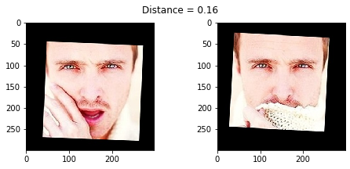

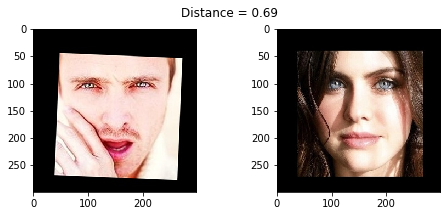

```python
import matplotlib.pyplot as plt

def show_pair(idx1, idx2):
    plt.figure(figsize=(8,3))
    plt.suptitle(f'Distance = {distance(embeddings[idx1], embeddings[idx2]):.2f}')
    plt.subplot(121)
    plt.imshow(load_image(metadata[idx1].image_path()))
    plt.subplot(122)
    plt.imshow(load_image(metadata[idx2].image_path()));

show_pair(2, 3)
show_pair(2, 180)
```

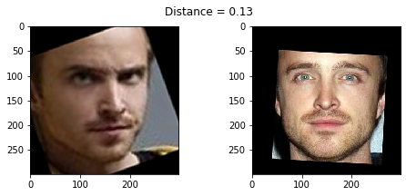

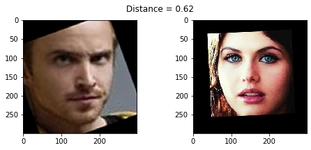

```python
show_pair(30, 31)
show_pair(30, 100)
```

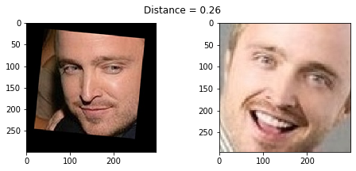

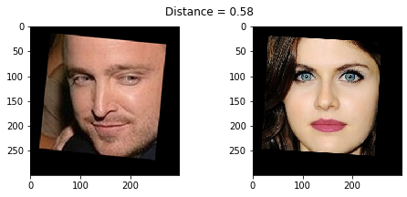

```python
show_pair(70, 72)
show_pair(70, 115)
```

### Create train and test sets (5 marks)

- Create X_train, X_test and y_train, y_test
- Use train_idx to seperate out training features and labels
- Use test_idx to seperate out testing features and labels

```python
train_idx = np.arange(metadata.shape[0]) % 9 != 0     #every 9th example goes in test data and rest go in train data
test_idx = np.arange(metadata.shape[0]) % 9 == 0

# one half as train examples of 10 identities
X_train = embeddings[train_idx]
# another half as test examples of 10 identities

#### Add your code here ####
X_test = embeddings[test_idx]


targets = np.array([m.name for m in metadata])
#train labels
y_train = targets[train_idx]
#test labels
#### Add your code here ####
y_test = targets[test_idx]
```

### Encode the Labels (3 marks)

- Encode the targets
- Use LabelEncoder

```python
from sklearn.preprocessing import LabelEncoder

#### Add your code here ####
encoder=LabelEncoder()
y_train=encoder.fit_transform(y_train)
y_test=encoder.transform(y_test)
```

### Standardize the feature values (3 marks)

- Scale the features using StandardScaler

```python
# Standarize features
from sklearn.preprocessing import StandardScaler

#### Add your code here ####
sd=StandardScaler()
X_train_std=sd.fit_transform(X_train)
X_test_std=sd.transform(X_test)
```

### Reduce dimensions using PCA (3 marks)

- Reduce feature dimensions using Principal Component Analysis
- Set the parameter n_components=128

```python
from sklearn.decomposition import PCA

#### Add your code here ####
pca = PCA(n_components=128,svd_solver='randomized',whiten=True)

pca.fit(X_train_std)

X_train_pca=pca.transform(X_train_std)
X_test_pca=pca.transform(X_test_std)

print(pca.explained_variance_ratio_)
print(pca.components_)
```

```
[0.1354529  0.05479336 0.04045055 0.03631844 0.03423571 0.03087334
 0.0249169  0.02379828 0.0210143  0.0195456  0.01803882 0.01721031
 0.01686429 0.01445104 0.01435649 0.01365032 0.0132095  0.01224699
 0.01164601 0.01145622 0.01098359 0.0105496  0.00978054 0.0093882
 0.00920078 0.0088415  0.00836907 0.00777003 0.00763532 0.00735128
 0.00677154 0.00641559 0.00635007 0.00627731 0.00574451 0.00545098
 0.005252   0.00506325 0.00501444 0.00483508 0.00450494 0.00424109
 0.00401508 0.00395254 0.00372432 0.00355339 0.00345348 0.00335365
 0.00325048 0.00319826 0.00314488 0.00307429 0.00295983 0.00285493
 0.00283025 0.00273343 0.00265769 0.00261316 0.00253078 0.00252956
 0.00238099 0.00230636 0.00224216 0.0021611  0.0020856  0.00203773
 0.00201153 0.00197303 0.00190038 0.00185148 0.00184669 0.00179115
 0.00178718 0.00173762 0.00170822 0.00166435 0.00163277 0.0016207
 0.00160335 0.00157768 0.00151247 0.00148036 0.00146067 0.00143738
 0.00140886 0.00136968 0.00135077 0.00133289 0.0013274  0.00130064
 0.00128564 0.0012442  0.00123091 0.00122532 0.00121972 0.00119363
 0.00118842 0.00117407 0.00114583 0.00111978 0.00110527 0.00109517
 0.00108489 0.00106781 0.00105858 0.00104105 0.00102632 0.00102297
 0.00100634 0.00097561 0.00096611 0.00095893 0.00093816 0.00093504
 0.00093263 0.00090717 0.00089627 0.00088788 0.00087375 0.00087044
 0.00086436 0.00085239 0.00084399 0.00082922 0.00081731 0.00079019
 0.00078819 0.00078572]
[[-0.02332127  0.0095382  -0.00185677 ... -0.0089365   0.0214772
   0.03938324]
 [ 0.02125035 -0.00020564  0.00943093 ... -0.0239683  -0.0032615
   0.01230726]
 [ 0.0012016  -0.00259168 -0.01237097 ...  0.01116986 -0.00493274
  -0.02071589]
 ...
 [ 0.01270087 -0.02326672  0.00925623 ...  0.00668924  0.02699873
   0.01258127]
 [ 0.01871471  0.01010664  0.00892365 ...  0.00655279  0.01039378
  -0.00900823]
 [ 0.01817424 -0.00762325 -0.01365812 ... -0.00041836  0.03903412
   0.02475412]]
```

### Build a Classifier (3 marks)

- Use SVM Classifier to predict the person in the given image
- Fit the classifier and print the score

```python
from sklearn.svm import SVC

#### Add your code here ####
svc_model=SVC(C=10000, kernel='rbf', gamma=0.005)
svc_model.fit(X_train_pca,y_train)
```

```
SVC(C=10000, cache_size=200, class_weight=None, coef0=0.0,
  decision_function_shape='ovr', degree=3, gamma=0.005, kernel='rbf',
  max_iter=-1, probability=False, random_state=None, shrinking=True,
  tol=0.001, verbose=False)
```

```python
y_pred = svc_model.predict(X_test_pca)

print(svc_model.score(X_train_pca,y_train))
print(svc_model.score(X_test_pca,y_test))
```

```
0.9997854077253219
0.9571183533447685
```

```python
from sklearn.metrics import classification_report,confusion_matrix

print(classification_report(y_test, y_pred, target_names=encoder.classes_))
```

```
                               precision    recall  f1-score   support

              pins_Aaron Paul       1.00      1.00      1.00        10
            pins_Alvaro Morte       1.00      1.00      1.00        10
             pins_Amanda Crew       1.00      0.93      0.96        14
          pins_Amaury Nolasco       1.00      1.00      1.00        12
               pins_Anna Gunn       1.00      1.00      1.00         7
    pins_Benedict Cumberbatch       0.89      0.89      0.89         9
            pins_Betsy Brandt       0.86      0.86      0.86         7
        pins_Brenton Thwaites       0.93      1.00      0.97        14
            pins_Brit Marling       1.00      1.00      1.00        14
          pins_Bryan Cranston       0.90      1.00      0.95         9
              pins_Caity Lotz       0.87      0.93      0.90        14
        pins_Cameron Monaghan       0.92      1.00      0.96        12
          pins_Chance Perdomo       1.00      1.00      1.00        10
             pins_Chris Evans       1.00      1.00      1.00        10
             pins_Chris Pratt       1.00      1.00      1.00        15
          pins_Cobie Smulders       1.00      1.00      1.00        15
      pins_Danielle Panabaker       0.92      0.92      0.92        12
             pins_Dave Franco       1.00      1.00      1.00        14
         pins_Dominic Purcell       1.00      0.92      0.96        12
          pins_Dwayne Johnson       0.93      1.00      0.97        14
           pins_Emilia Clarke       0.89      1.00      0.94        17
     pins_Emily Bett Rickards       0.82      1.00      0.90         9
              pins_Emma Stone       0.87      0.93      0.90        14
         pins_Gwyneth Paltrow       1.00      0.93      0.96        14
             pins_Henry Cavil       0.93      0.87      0.90        15
             pins_Jason Momoa       1.00      1.00      1.00        14
           pins_Jeremy Renner       0.92      0.92      0.92        13
         pins_Jesse Eisenberg       1.00      0.91      0.95        11
             pins_Jim Parsons       0.86      1.00      0.92        12
            pins_Jon Bernthal       1.00      0.86      0.92         7
             pins_Josh Radnor       1.00      1.00      1.00        11
           pins_Kit Harington       1.00      1.00      1.00        11
          pins_Krysten Ritter       1.00      1.00      1.00        12
         pins_Kumail Nanjiani       1.00      0.90      0.95        10
         pins_Maisie Williams       1.00      0.94      0.97        16
            pins_Mark Ruffalo       0.93      1.00      0.96        13
            pins_Martin Starr       1.00      0.83      0.91         6
          pins_Melissa benoit       0.93      1.00      0.96        13
```

[output cut: 49 more lines]

```
           pins_miguel herran       1.00      1.00      1.00         9
      pins_millie bobby brown       1.00      1.00      1.00         9
                 pins_rihanna       1.00      1.00      1.00        14
   pins_robert downey jr face       1.00      0.92      0.96        12
            pins_sean pertwee       1.00      0.78      0.88         9
            pins_selena gomez       1.00      0.91      0.95        11
                 pins_shakira       1.00      1.00      1.00         5
          pins_tati gabrielle       0.88      1.00      0.93         7
            pins_taylor swift       1.00      1.00      1.00        11
        pins_tom holland face       1.00      1.00      1.00        13
                 pins_zendaya       1.00      0.85      0.92        13

                    micro avg       0.96      0.96      0.96      1166
                    macro avg       0.96      0.95      0.95      1166
                 weighted avg       0.96      0.96      0.96      1166
```

```python
print(confusion_matrix(y_test, y_pred, labels=range(encoder.classes_.size)))
```

```
[[10  0  0 ...  0  0  0]
 [ 0 10  0 ...  0  0  0]
 [ 0  0 13 ...  0  0  0]
 ...
 [ 0  0  0 ... 11  0  0]
 [ 0  0  0 ...  0 13  0]
 [ 0  0  0 ...  0  0 11]]
```

### Test results (1 mark)

- Take 10th image from test set and plot the image
- Report to which person(folder name in dataset) the image belongs to

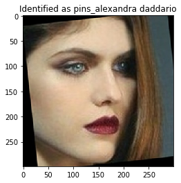

```python
 import warnings
# Suppress LabelEncoder warning
warnings.filterwarnings('ignore')

example_idx = 10

example_image = load_image(metadata[test_idx][example_idx].image_path())
#### Add your code here ####
example_prediction = svc_model.predict(X_test_pca[[example_idx]])
example_identity = encoder.inverse_transform(example_prediction)[0]

plt.imshow(example_image)
plt.title(f'Identified as {example_identity}');
```

```python
## verified the image under test at orignal folder
metadata[test_idx][10]
```

```
D:\PG-AIML\Labs\Assessment\Project14-Advance Computer Vision with CNN__Project_FaceRecognition//PINS\pins_alexandra daddario\alexandra daddario101.jpg
```

We have verified that the predicted person is indeed Alexandra Daddario